# 20221_M2.855_PEC4-gvillalbaa

[figure not shown]

M2.855 · Modelos avanzados de minería de datos · PEC4

2022-1 · Máster universitario en Ciencia de datos (Data science)

Estudios de Informática, Multimedia y Telecomunicación

# PEC 4: Series temporales y combinación de modelos de clasificación

Está práctica está dividida en dos partes:

- En el primer ejercicio veremos cómo descomponer y componer series temporales para realizar predicciones a futuro.
- En el segundo ejercicio estudiaremos diferentes técnicas mediante las que podremos combinar el resultado de múltiples clasificadores.

Para esta PEC se deben usar **únicamente las librerías que se importan a continuación**. Si se desea usar otra librería hay que consultarlo con el tutor/tutora del aula.

**Importante: cada uno de los ejercicios puede suponer varios minutos de ejecución, por lo que la entrega debe hacerse en formato notebook y en formato HTML donde se vea el código, los resultados y los comentarios de cada ejercicio. Para exportar el notebook a HTML puede hacerse desde el menú File $\to$ Download as $\to$ HTML.**

**Nombre y apellidos: Gerson Villalba Arana**

Para ello vamos a necesitar las siguientes librerías:

```python
from matplotlib import pyplot as plt
import numpy as np
import pandas as pd
import pickle
import scipy.stats
from sklearn.ensemble import GradientBoostingClassifier, RandomForestClassifier
from sklearn.linear_model import LinearRegression
from sklearn.metrics import accuracy_score
from sklearn.model_selection import cross_val_score, train_test_split, validation_curve
from sklearn.neighbors import KNeighborsClassifier
from sklearn.preprocessing import OneHotEncoder
from sklearn.svm import SVC
from sklearn.tree import DecisionTreeClassifier
from sklearn.model_selection import GridSearchCV
import seaborn as sns

%matplotlib inline
```

```python
# Set Seaborn aesthetics
sns.set_style('darkgrid')
plt.rcParams['figure.figsize'] = (6,4)
plt.rcParams['lines.linewidth'] = 2
plt.rcParams['axes.titlesize'] = 14
plt.rcParams['axes.titlelocation'] = 'left'
plt.style.use('ggplot')
```

# 1. Series temporales (6 puntos)

En este primer ejercicio trabajaremos las series temporales. Para ello, usaremos el dataset *AirPassangers* que contiene información del número de vuelos que se realizaron a lo largo de muchos años.

Empezaremos leyendo los datos y observando gráficamente su distribución. Como se puede apreciar es un claro caso de serie temporal, con heterocedasticidad, tendencia, periodo y ruido. A lo largo de este ejercicio trataremos cada uno de estos puntos.

```python
data = pd.read_csv('AirPassengers.csv', parse_dates=['Month'], index_col='Month', header=0)
data.head()
```

| Month | Passengers |
| --- | --- |
| 1949-01-01 | 112 |
| 1949-02-01 | 118 |
| 1949-03-01 | 132 |
| 1949-04-01 | 129 |
| 1949-05-01 | 121 |

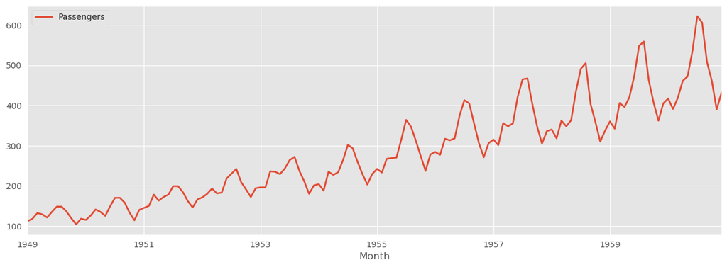

```python
data.plot(figsize=(15, 5))
```

Antes de empezar a tratar las diferentes componenetes de una serie temporal, eliminaremos del dataset original un par de años de datos. Así cuando hagamos una predicción a futuro podremos comprobar si se ajusta a los datos reales.

```python
TEST_SIZE = 24
train, test = data.iloc[:-TEST_SIZE].to_numpy(), data.iloc[-TEST_SIZE:].to_numpy()
x_train, x_test = np.arange(train.shape[0]), np.arange(train.shape[0], data.shape[0])
train.shape, x_train.shape, test.shape, x_test.shape
```

```
((120, 1), (120,), (24, 1), (24,))
```

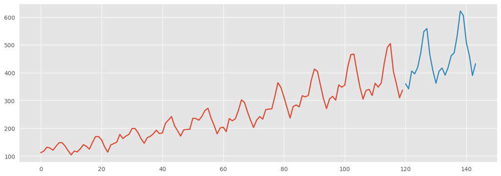

```python
fig, ax = plt.subplots(1, 1, figsize=(15, 5))
ax.plot(x_train, train)
ax.plot(x_test, test)
```

## 1.1 Componentes de la serie temporal

### 1.1.a. Heterocedasticidad

Se dice que una serie temporal tiene heterocedasticidad cuando la variancia varía con el tiempo (https://es.wikipedia.org/wiki/Heterocedasticidad). En nuestro caso, observamos que tenemos heterocedasticidad, ya que la amplitud de onda varía con el tiempo. En este primer apartado debéis eliminar la heterocedasticidad de la serie temporal. Es decir, que la diferencia entre el mínimo y el máximo de la estacionalidad (anual) sea más o menos la misma a lo largo del tiempo.

**Implementación:** transforma los datos para eliminar la heterocedasticidad. Para ello debéis transformar los datos aplicando la función que consideréis que elimina mejor la heterocedasticidad en el dataset (exponencial, logarítmica, ...). Estas funciones ya están implementadas en numpy. Graficar los datos originales junto con los datos transformados.

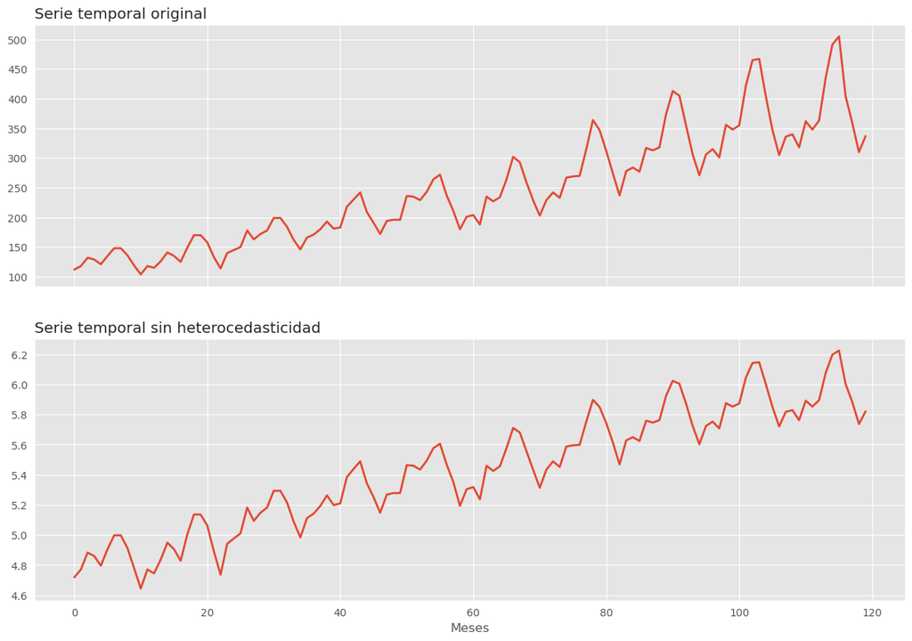

```python
df = pd.DataFrame({'original': train.squeeze(),
                   'log-transformed': np.log(train).squeeze()},
                  index=x_train)
fig, ax = plt.subplots(2, 1, figsize=(15, 10), sharex=True)
ax[0].plot(df.index, df['original'])
ax[0].set_title('Serie temporal original')
ax[1].plot(df.index, df['log-transformed'])
ax[1].set_title('Serie temporal sin heterocedasticidad')
ax[1].set_xlabel('Meses')
plt.show()
```

Vemos gráficamente como al realizar la tranformación logarítmica la variancia de la serie temporal se mantiene constante a lo largo del tiempo y, por lo tanto, podemos decir que hemos eliminado la heterocedasticidad de la serie temporal. Podríamos comprobarlo con un test de Breusch-Pagan, que mediante un contraste de hipótesis nos permitiría comprobar si la variancia es realmente constante o no.

### 1.1.b. Tendencia

La tendencia es el comportamento que tienen los datos a largo plazo (https://miro.medium.com/max/1872/1*rDQL2fAp_X_dgAHNZuwRfw.png). En nuestra serie temporal tenemos una tendencia lineal creciente. En este apartado debéis eliminar la tendencia, quedando una serie temporal con tendencia constante.

**Implementación:** elimina la tendencia de los datos. Observando la serie podemos apreciar que tenemos una tendencia lineal, por ese motivo podemos ajustar una regresión lineal (usando scikit-learn) y sustraerla a los datos originales (sin heterocedasticidad). Graficar los datos con tendencia junto con los datos sin tendencia.

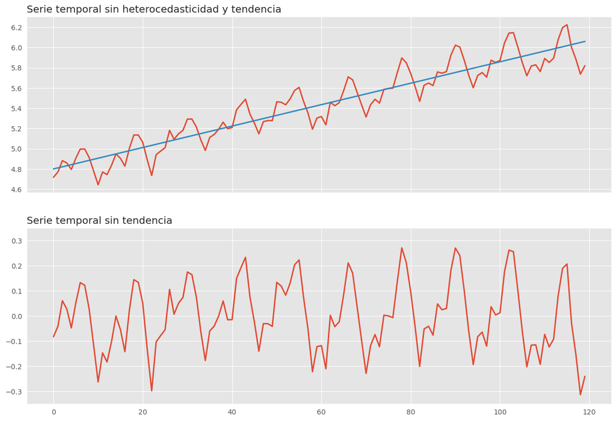

```python
# Ajustar un modelo de regresión lineal a los datos de entrenamiento
linreg = LinearRegression().fit(df.index.values.reshape(-1,1), df['log-transformed'])
# Obtenemos la recta de tendencia
df['trend'] = linreg.predict(df.index.values.reshape(-1,1))
# Eliminamos la tendencia de la serie temporal
df['woTrend'] = df['log-transformed'] - df['trend']
# Graficamos la serie temporal y la recta de tendencia
fig, ax = plt.subplots(2, 1, figsize=(15, 10), sharex=True)
ax[0].plot(df.index, df['log-transformed'], label='Serie temporal')
ax[0].plot(df.index, df['trend'], label='Tendencia')
ax[0].set_title('Serie temporal sin heterocedasticidad y tendencia')
ax[1].plot(df.index, df['woTrend'], label='Serie sin tendencia')
ax[1].set_title('Serie temporal sin tendencia')
ax[1].set_ylim(-0.35, 0.35)
plt.show()
```

### 1.1.c. Estacionalidad

Definimos la estacionalidad como la variación cíclica que se produce en los datos (https://es.wikipedia.org/wiki/Estacionalidad). En este apartado se debe encontrar y eliminar la estacionalidad.

#### 1.1.c.a. Encontrar el periodo de la estacionalidad

**Implementación:** en primer lugar debeis encontrar el ciclo, es decir, cada cuánto se repiten los datos. Para ello podemos usar la autocorrelación (numpy te permite obtener los coeficientes de correlación). Graficar los coeficientes para los 22 primeros valores de autocorrelación y determinar su valor máximo, está será nuestra estacionalidad. Dar una interpretación semántica del resultado obtenido.

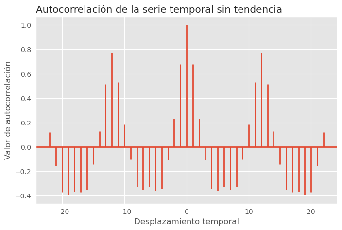

```python
plt.subplots(figsize=(8,5))
plt.acorr(df['woTrend'], maxlags = 22)
plt.title('Autocorrelación de la serie temporal sin tendencia')
plt.xlabel('Desplazamiento temporal')
plt.ylabel('Valor de autocorrelación')
plt.show()
```

En la gráfica anterior estamos mostrando la autocorrelación de la serie temporal con ella misma desplazada una cantidad de ciclo. Se puede ver como el máximo de esta autocorrelación se da para un desplazamiento de cero, como es lógico, pues es la correlación con la misma señal sin desplazar, que da una valor unitario. Quitando ese caso, el máximo de correlación se observa para un desplazamiento de 12, es decir, para la serie temporal correlada con ella misma desplazada 12 muestras o, lo que es lo mismo, un año. Podemos concluir por lo tanto que este es el período de la señal y por lo tanto la estacionalidad de la serie temporal es anual. Hay que destacar además que tenemos para ese período un valor de correlación muy alto, de casi 0.8, por lo que podemos decir que la estacionalidad es muy marcada.

#### 1.1.c.b. Calcular el patron de estacionalidad

**Implementación:** ahora que ya conocéis el ciclo, debéis calcular el patrón (el molde de la estacionalidad). Es decir, para cada punto, calcular la mediana de ese punto en cada uno de los ciclos de la serie.

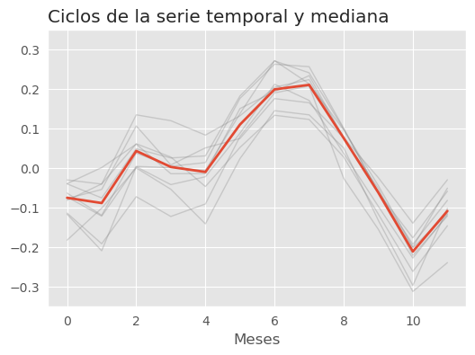

```python
fig, ax = plt.subplots()
for cycle in df['woTrend'].values.reshape(-1,12):
    ax.plot(range(len(cycle)), cycle, color='gray', alpha=0.3, lw=1)
cycle_median = np.median(df['woTrend'].values.reshape(-1,12), axis=0)
ax.plot(range(len(cycle_median)), cycle_median)
ax.set_title('Ciclos de la serie temporal y mediana')
ax.set_ylim(-0.35, 0.35)
ax.set_xlabel('Meses')
plt.show()
```

Podemos ver superpuestos todos los ciclos de la serie temporal y la mediana resultante de todos ellos, que es el patrón de la estacionalidad.

**Implementación:** una vez obtenido el patrón, replicadlo a lo largo de toda la serie temporal. Cuando lo hayáis calculado debéis restarlo de la serie temporal (sin tendencia ni heterocedasticidad). Graficar los datos con estacionalidad junto con los datos sin estacionalidad.

A continuación replicamos el patrón de estacionalidad a lo largo de toda la serie temporal para poder eliminar esta estacionalidad de la serie temporal.

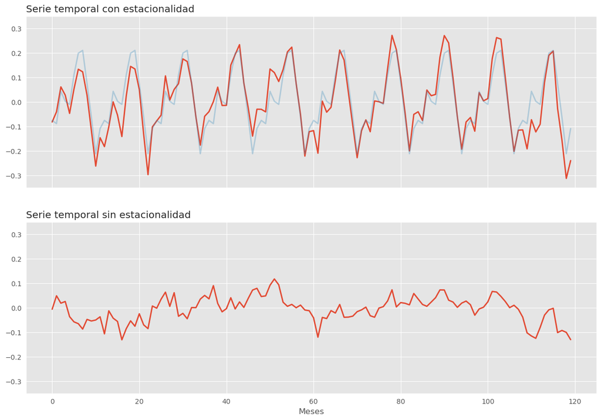

```python
df['seasonality'] = np.concatenate([cycle_median] * 10, axis=0)
# Eliminamos la estacionalidad de la serie temporal
df['woSeasonality'] = df['woTrend'] - df['seasonality']
# Graficamos la serie temporal
fig, ax = plt.subplots(2, 1, figsize=(15, 10), sharex=True)
ax[0].plot(df.index, df['woTrend'], label='Tendencia')
ax[0].plot(df.index, df['seasonality'], label='Estacionalidad', alpha=0.3)
ax[0].set_title('Serie temporal con estacionalidad')
ax[0].set_ylim(-0.35, 0.35)
ax[1].plot(df.index, df['woSeasonality'], label='Serie sin tendencia')
ax[1].set_title('Serie temporal sin estacionalidad')
ax[1].set_ylim(-0.35, 0.35)
ax[1].set_xlabel('Meses')
plt.show()
```

En la primera gráfica podemos ver la serie temporal original sin tendencia, además de la estacionalidad que hemos calculado a partir del patrón de estacionalidad (que hemos replicado todos los ciclos). En la segunda gráfica podemos ver la serie temporal una vez eliminada la estacionalidad además de la tendencia que ya hemos eliminado con anterioridad, por lo que nos queda es el ruido.

### 1.1.d. Ruido

Una vez eliminadas la heterocedasticidad, la tendencia y la estacionalidad, lo que nos queda es el ruido. El ruido sigue una distribución normal. En este apartado debeis encontrar los parámetros de la distribución que sigue el ruido (media y desviación estandard).

```python
noise_mean, noise_std = df['woSeasonality'].mean(), df['woSeasonality'].std()
noise_model = np.random.normal(noise_mean, noise_std, df['woSeasonality'].shape[0])
```

## 1.2. Predicción

Vamos a predecir los dos proximos años y comparar la predicción con los datos reales. Para ello seguiremos los siguientes pasos:

- Generar ruido
- Añadir estacionalidad
- Añadir tendencia
- Añadir heterocedasticidad

### 1.2.a. Ruido

Como hemos visto que el ruido se distribuye aleatoriamente siguiendo una distribución normal, vamos a generar ruido siguiendo esta distribución.

**Implementación:** genera dos años de datos de ruido (24 muestras) usando la distribución encontrada en el apartado 1.1.d. Podéis usar el módulo random de numpy. Grafica los resultados.

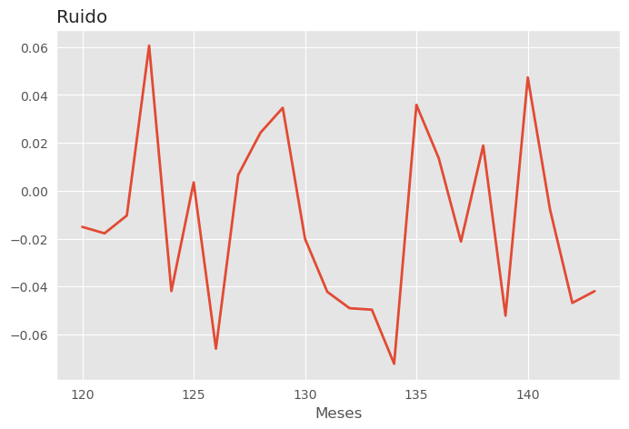

```python
df_model = pd.DataFrame(np.random.normal(noise_mean, noise_std, 24),
                        columns=['noise'], index=range(120, 144))

fig, ax = plt.subplots(figsize=(8, 5))
ax.plot(df_model.index, df_model['noise'])
ax.set_title('Ruido')
ax.set_xlabel('Meses')
plt.show()
```

### 1.2.b. Estacionalidad

Anteriormente hemos calculado la estacionalidad y el ciclo de la serie temporal. Vamos a usar esta estacionalidad ya calculada para añadirla a nuestra predicción.

**Implementación:** añade a los dos años de ruido calculados en el apartado anterior los dos años de estacionalidad encontrada en el apartado 1.1.c. Grafica los resultados.

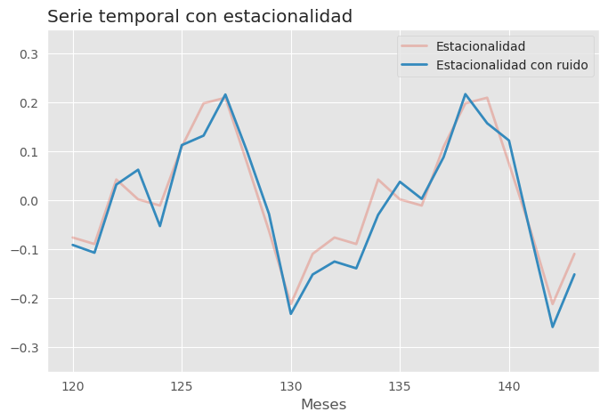

```python
df_model['seasonality'] = np.concatenate([cycle_median] * 2, axis=0)
df_model['wSeasonality'] = df_model['seasonality'] + df_model['noise']

fig, ax = plt.subplots(figsize=(8, 5))
ax.plot(df_model.index, df_model['seasonality'], label='Estacionalidad', alpha=0.3)
ax.plot(df_model.index, df_model['wSeasonality'], label='Estacionalidad con ruido')
ax.set_title('Serie temporal con estacionalidad')
ax.set_xlabel('Meses')
ax.set_ylim(-0.35, 0.35)
ax.legend()
plt.show()
```

### 1.2.c. Tendencia

Anteriormente hemos visto que los datos de la serie temporal tienen una tendencia lineal y la hemos calculado mediante una regresión lineal. Vamos a añadir esta tendencia a nuestra predicción.

**Implementación:** añade a los dos años de ruido + estacionalidad calculados en el apartado anterior la tendencia encontrada en el apartado 1.1.b. Grafica los resultados.

Para calcular la tendencia, hemos usado el modelo de regresión lineal, por lo que la tendencia que hemos entrenado antes, y lo utilizamos para predecir los dos años siguientes (24 muestras).

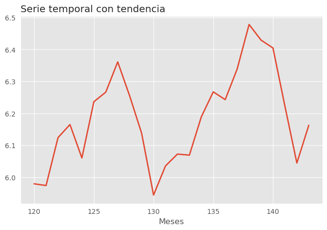

```python
# Obtenemos la recta de tendencia
df_model['trend'] = linreg.predict(df_model.index.values.reshape(-1,1))
df_model['wTrend'] = df_model['wSeasonality'] + df_model['trend']

# Graficamos la serie temporal
fig, ax = plt.subplots(figsize=(8, 5))
ax.plot(df_model.index, df_model['wTrend'])
ax.set_title('Serie temporal con tendencia')
ax.set_xlabel('Meses')
plt.show()
```

### 1.2.d. Heterocedasticidad

En el primer apartado de esta práctica hemos visto que la serie temporal tiene heterocedasticidad y la hemos eliminado transformando los datos. En este apartado haremos la transfromación inversa para añadir heterocedasticidad a nuestra predicción.

**Implementación:** añade a los dos años de ruido + estacionalidad + tendencia calculados en el apartado anterior la heterocedasticidad aplicando la función inversa a la encontrada en el apartado 1.1.a. Grafica el resultado junto con la serie completa y compara la predicción obtenida con los datos reales.

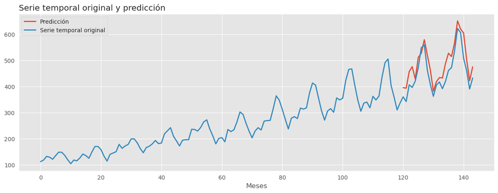

```python
df_model['exp-transformed'] = np.exp(df_model['wTrend'])

fig, ax = plt.subplots(figsize=(15, 5))
ax.plot(df_model.index, df_model['exp-transformed'], label='Predicción')
ax.plot(range(data.shape[0]), data, label='Serie temporal original')
ax.set_title('Serie temporal original y predicción')
ax.set_xlabel('Meses')
ax.legend()
plt.show()
```

Vemos en la gráfica de color azul la serie original, cuyas primeras 120 muestras (10 años) hemos utilizado para predecir los dos años posteriores, que mostramos en rojo. Como se puede comprobar, la predicción obtenida es bastante buena, ya que se ajusta bastante bien a los datos reales de los que disponemos, si bien es cierto que se ha sobre-estimado ligeramente su valor en casi todos los puntos, lo cual lleva a pensar que quizás el modelo de tendencia (modelo regresión lineal) no es del todo adecuado para este caso.

**[Bonus] Implementación:** como la distribución del ruido generado es aleatoria, en cada ejecución obtendremos predicciones distintas. Una manera de asegurar que la predicción obtenida es fiable es generando intervalos de confianza.

Para ello vamos a repetir los pasos anteriores pero generando 500 muestras de dos años de longitud cada una (o sea 500 predicciones). Una vez generadas definimos: - Intervalo de confianza = (min(predicciones), max(predicciones)) - Predicción final = median(predicciones) Graficar: - La serie temporal entera - Los dos años de predicción (mediana de las 500 muestras de predicción) - El valor real de los dos años que hemos predicho - Los intérvalos de confianza (min y max de las 500 muestras de predicción) Para graficar los intérvalos de confianza podéis usar fill_between de matplotlib.

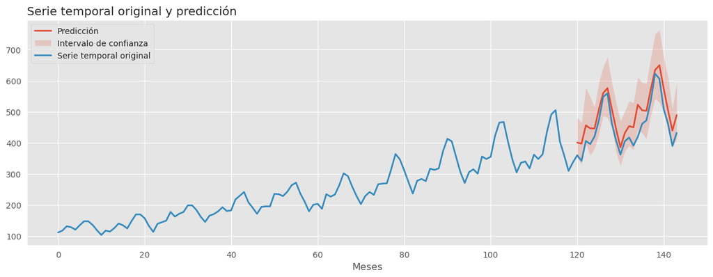

```python
# Noise generation
noise = np.random.normal(noise_mean, noise_std, 24*500).reshape(24,-1)
# Add trend and seasonality
trend_seas = noise + df_model['seasonality'].values.reshape(-1,1) + df_model['trend'].values.reshape(-1,1)
# Exponential transformation
signal_rec = np.exp(trend_seas)
# CI and median
ci_sup, ci_inf = signal_rec.max(axis=1), signal_rec.min(axis=1)
pred = np.median(signal_rec, axis=1)
# Plot
fig, ax = plt.subplots(figsize=(15, 5))
ax.plot(df_model.index, pred, label='Predicción')
ax.fill_between(df_model.index, ci_inf, ci_sup, alpha=.2, label='Intervalo de confianza')
ax.plot(range(data.shape[0]), data, label='Serie temporal original')
ax.set_title('Serie temporal original y predicción')
ax.set_xlabel('Meses')
ax.legend(loc='upper left')
plt.show()
```

Vemos como ahora la predicción mediana (roja) sigue estando en todos los puntos por encima de la señal real (azul), pero sin embargo esta última sí que entra dentro del intervalo de confianza tal y como lo hemos definido a excepción de un punto, lo cual nos indica que la predicción es bastante fiable, a pesar de la ligera sobre-estimación que hemos realizado.

# 2. Combinación de clasificadores (5 puntos)

En este ejercicio utilizaremos un subconjunto de 5.000 imágenes provenientes del corpus EMNIST, constituido por carácteres y dígitos escritos a mano . Dicho subconjunto está formado por 1.000 imágenes para cada una de las 5 clases diferentes ("A", "B", "C", "D" y "E").

La primera parte de este ejercicio abordará la combinación de clasificadores en paralelo mediante las tecnicas de *Bagging* y *Boosting*.

Mientras que la segunda parte pretende mejorar los resultados aplicando tecnicas de combinación secuencial de clasificadores: *Stacking* y *Cascading*.

Para empezar, vamos a visualizar el dataset. Las imágenes tienen una resolución de 28x28 píxeles en escala de grises, por lo que se pueden representar utilizando un vector de 784 posiciones. El siguiente código cargará las 5.000 imágenes en la variable images y las correspondientes etiquetas (en forma numérica) en la variable labels. Podemos comprobar que la carga ha sido correcta obteniendo las dimensiones de estas dos variables.

```python
with open("data.pickle", "rb") as f:
    data = pickle.load(f)

images = data["images"]
labels = data["labels"]
n_classes = 5
labels_text = ["A", "B", "C", "D", "E"]

print("Dimensiones del vector de imágenes: {}".format(images.shape))
print("Dimensiones del vector de etiquetas: {}".format(labels.shape))
```

```
Dimensiones del vector de imágenes: (5000, 784)
Dimensiones del vector de etiquetas: (5000,)
```

Con el siguiente código podemos ver un ejemplo de imagen de cada una de las clases. Para ello reajustamos el vector de 784 dimensiones que representa cada imagen en una matriz de tamaño 28x28 y la transponemos para mostrarla:

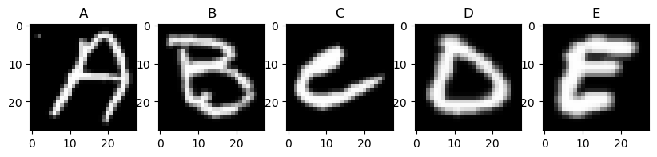

```python
fig, ax = plt.subplots(1, n_classes, figsize=(10,10))

idxs = [np.where(labels == i)[0] for i in range(n_classes)]

for i in range(n_classes):
    k = np.random.choice(idxs[i])
    ax[i].imshow(images[k].reshape(28, 28).transpose(), cmap="gray")
    ax[i].set_title("{}".format(labels_text[i]))
```

Para poder probar varios modelos, primero vamos a dividir el dataset en train y test.

La división con la función *train_test_split* es aleatoria , pero para que todos obtengáis los mismos resultados y poder comentar dudas por el foro, fijaremos la seed para obtener los mismos datasets de train y test. El *split* tendrá en cuenta que los dos conjuntos tengan el mismo número de ejemplos para cada una de las clases gracias al parámetro *stratify=labels*.

Como en la segunda parte de este ejercicio trataremos *stacking* y *cascading*, y ambos se aplican sobre el conjunto de test, haremos un *split* del 50% para tener un poco más de base al aplicar estas dos técnicas.

```python
myseed = 13

X_train, X_test, y_train, y_test = train_test_split(images, labels, test_size=0.5,
                                                    random_state=myseed,
                                                    stratify=labels)
```

## 2.1. Combinación paralela de clasificadores

### 2.1.1. Árbol de decisión

Para poder comparar el aumento de *performance* obtenido a medida que aplicamos técnicas nuevas, utilizaremos como *baseline* un simple árbol de decisión.

**Implementación:**  
Evalúa la precisión de un árbol de decisión con profundidad máxima de 5 niveles (aplicaremos la misma restricción en las siguientes secciones) aplicando validación cruzada sobre el conjunto de datos de train. A continuación, entrena el mismo modelo sobre el conjunto de train, calcula y guarda las predicciones sobre el conjunto de test y calcula la precisión en el conjunto de test. Sugerencia: usar el módulo *cross_val_score* de *sklearn*. Para aprender más sobre *cross validation* y sobre cómo usar estos módulos, os recomendamos los siguientes enlaces: - http://scikit-learn.org/stable/modules/cross_validation.html - http://scikit-learn.org/stable/modules/generated/sklearn.model_selection.cross_val_score.html

```python
def evaluate_clf(clf, X_train, y_train, X_test, y_test):
    cv_scores = cross_val_score(clf, X_train, y_train, cv=5, scoring='accuracy')
    print(f'La precision con validación cruzada es: {cv_scores.mean():.3f} +/- {cv_scores.std():.3f}')
    # Train the model with all training data
    clf.fit(X_train, y_train)
    # Model evaluation
    train_acc =  accuracy_score(y_train, clf.predict(X_train))
    print(f'La precision sobre el conjunto de entrenamiento es: {train_acc:.3f}')
    test_acc =  accuracy_score(y_test, clf.predict(X_test))
    print(f'La precision sobre el conjunto de test es: {test_acc:.3f}')
```

```python
DT = DecisionTreeClassifier(max_depth=5, random_state=myseed)
evaluate_clf(DT, X_train, y_train, X_test, y_test)
```

```
La precision con validación cruzada es: 0.793 +/- 0.019
La precision sobre el conjunto de entrenamiento es: 0.837
La precision sobre el conjunto de test es: 0.795
```

Como podemos destacar dos puntos importantes:

- La precisión sobre el conjunto de entrenamiento es notablemente superior a la precisión sobre el conjunto de test. Esto es un claro indicativo de *overfitting*, algo típico en árboles de decisión, pese a haber limitado la profundidad máxima a 5 niveles.
- La precisión obtenida sobre el conjunto de test es muy parecida a la obtenida con validación cruzada, algo lógico. La diferencia entre ambos es que el conjunto de test que se ha utilizado para cada caso es distinto, ya que con validación cruzada se ha utilizado como test un subconjunto del conjunto de train, y además se han tenido menos datos disponibles para entrenamiento en cada iteración. Por otro ladio, cross validation nos permite no perder datos para el entrenamiento separándolos y además nos permite obtener una estimación más fiable de la precisión del modelo, ya que podemos obtener una media con su desviación típica.

### 2.1.2. *Bagging*

#### 2.1.2.a. Random Forest

La idea básica del bagging es utilizar el conjunto de entrenamiento original para generar centenares o miles de conjuntos similares usando muestreo con reemplazo. En este concepto está basado el algoritmo Random Forest, la combinación de varios árboles de decisión, cada uno entrenado con una realización diferente de los datos. La decisión final del clasificador combinado (el Random Forest) se toma por mayoría, dando el mismo peso a todas las decisiones parciales tomadas por los clasificadores base (los árboles).

**Implementación:**  
Evalúa la precisión de un *random forest* combinando 20 árboles de decisión con profundidad máxima de 5 niveles aplicando validación cruzada sobre el conjunto de datos de train. A continuación, entrena el mismo modelo sobre el conjunto de train, calcula y guarda las predicciones sobre el conjunto de test y calcula la precisión en el conjunto de test. Sugerencia: usar el módulo *RandomForestClassifier* de *sklearn*. Para aprender a usar este módulo os recomendamos el siguiente enlace: - http://scikit-learn.org/stable/modules/generated/sklearn.ensemble.RandomForestClassifier.html

```python
RF = RandomForestClassifier(n_estimators=20, max_depth=5, random_state=myseed)
evaluate_clf(RF, X_train, y_train, X_test, y_test)
```

```
La precision con validación cruzada es: 0.882 +/- 0.020
La precision sobre el conjunto de entrenamiento es: 0.920
La precision sobre el conjunto de test es: 0.889
```

**Análisis:** ¿han mejorado los resultados respecto a un simple árbol de decisión? ¿Era de esperar?

Vemos que los resultados de Random Forest han sido notablemente mejores a los obtenidos con un árbol de decisión simple. Esto es de esperar, y confirma que la idea de *bagging* funciona, ya que al entrenar varios árboles de decisión con diferentes realizaciones de los datos, se consigue reducir la varianza del modelo, y por tanto, mejorar la precisión. Podemos comprobar además que han aumentado tanto la precisión sobre el conjunto de train como la precisión sobre el conjunto de test. Por otro lado, la diferencia entre la precisión entre ambos conjuntos evidencia la existencia de un ligero *overfitting* también en este caso. Nuevamente, la precisión calculada con validación cruzada es muy parecida a la precisión calculada sobre el conjunto de test, como cabría esperar.

#### 2.1.2.b. Out-of-bag

Una ventaja del *bagging* usado en el *Random Forest* es que cada uno de los árboles de decisión ha sido entrenado con una combinación diferente de los datos (muestreo con reemplazo), es decir, cada uno de los árboles no ha visto una determinada parte de los datos originales. Esto define una especie de conjunto de test para cada uno de los árboles, llamado *out-of-bag*, que puede ser usado para estimar el error del modelo sin necesidad de usar el conjunto de test real que creamos previamente, ni de usar estrategias de *cross-validation*.

**Implementación:**  
Entrena sobre el conjunto de train un modelo de *random forest*combinando 20 árboles de decisión con profundidad máxima de 5 niveles y muestra la precisión de este modelo en el *out-of-bag*. Sugerencia: usar el módulo *RandomForestClassifier* de *sklearn*. Para aprender más sobre *out-of-bag* y sobre como usar este módulo (incluyendo el atributo *oob_score_*), os recomendamos los siguientes enlaces: - http://scikit-learn.org/stable/modules/generated/sklearn.ensemble.RandomForestClassifier.html - http://scikit-learn.org/stable/auto_examples/ensemble/plot_ensemble_oob.html

```python
RF = RandomForestClassifier(n_estimators=20, max_depth=5, random_state=myseed, oob_score=True)
RF.fit(X_train, y_train)
print(f'La precisión out-of-bag es: {RF.oob_score_}')
```

```
La precisión out-of-bag es: 0.8624
```

**Análisis:** ¿la precisión obtenida en el *out-of-bag* y con los métodos de validación anteriores son comparables? ¿Era de esperar?

Vemos que la precisión que hemos obtenido con los datos out-of-bag es muy similar a la que hemos obtenido con el conjunto de test o con cross-validation en el apartado anterior. Esto es de esperar, ya que el conjunto out-of-bag con datos que cada uno de los modelos de Random Forest no ha visto en la fase de entrenamiento, y por lo tanto son válidos para ser usados en la evaluación del modelo.

#### 2.1.2.c. Número de clasificadores agregados

En los ejercicios anteriores hemos combinado 20 clasificadores simples en nuestro clasificador combinado. ¿Será que la precisión del clasificador combinado aumenta indefinidamente su desempeño si añadimos más clasificadores?

Para responder a esta pregunta vamos a representar una curva de validación. La curva de validación es una representación gráfica del desempeño de un modelo variando uno de sus parámetros. Esto nos permite entender cuál es el impacto de un determinado parámetro en el desempeño de un modelo.

**Implementación:**  
Entrena varios modelos de Random Forest con un número de árboles cada vez mayor. Para cada modelo, calcula su precisón en el conjunto de test o usando *cross-validation* en el conjunto de entrenamiento. Opcional: representa gráficamente la evolución de la precisión con el número de árboles para ayudarte en el análisis de los resultados.  
Sugerencia: usar el módulo *validation_curve* de sklearn. Para aprender a usar este módulo os recomendamos los siguientes enlaces:  
- http://scikit-learn.org/stable/modules/generated/sklearn.model_selection.validation_curve.html  
- http://scikit-learn.org/stable/modules/learning_curve.html#validation-curve

```python
RF = RandomForestClassifier(n_estimators=20, max_depth=5, random_state=myseed)
n_estimators_grid = range(10, 201, 10)
train_scores, test_scores = validation_curve(RF, X_train, y_train,
                                           param_name='n_estimators',
                                           param_range=n_estimators_grid,
                                           cv=5, n_jobs=-1)
```

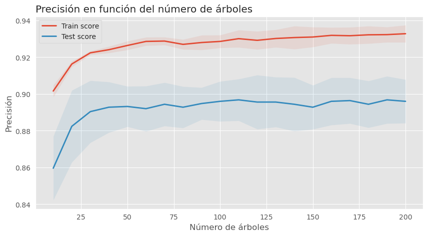

```python
# Compute mean and confidence interval
mean_train = train_scores.mean(axis=1)
ci_train = train_scores.std(axis=1)
mean_test= test_scores.mean(axis=1)
ci_test = test_scores.std(axis=1)
# Plot training accuracy
fig, ax = plt.subplots(figsize=(10, 5))
ax.plot(n_estimators_grid, mean_train, label='Train score')
ax.fill_between(n_estimators_grid, (mean_train-ci_train), (mean_train+ci_train), alpha=.1)
# Plot test accuracy
ax.plot(n_estimators_grid, mean_test, label='Test score')
ax.fill_between(n_estimators_grid, (mean_test-ci_test), (mean_test+ci_test), alpha=.1)

ax.set_xlabel('Número de árboles')
ax.set_ylabel('Precisión')
ax.set_title('Precisión en función del número de árboles')
ax.legend()
plt.show()
```

**Análisis:** ¿incrementa indefinidamente la precisión con el número de árboles combinados o se satura en una precisión límite? ¿Por qué?

De la gráfica anterior podemos ver como la precisión tanto en el conjunto de entrenamiento como en el conjunto de test aumenta con el número de árboles combinados hasta cierto punto en torno a 40 árboles. A partir de ahí, la precisión en el conjunto de entrenamiento sigue aumentando ligeramente, pero la precisión en el conjunto de test (que es la que nos importa) se queda estable en en rango del 89%. Esto es debido a que el modelo empieza a sobreajustarse a los datos de entrenamiento, y por lo tanto no es capaz de generalizar correctamente a nuevos datos, produciéndose un *overfitting* cada vez mayor. Por lo tanto, no merece la pena seguir aumentando el número de árboles combinados, a partir de este punto, ya que la precisión no aumenta y sí aumenta el tiempo de entrenamiento.

Se puede observar también como el intervalo de confianza de la precisión en el conjunto de test es bastante grande en comparación con lo que observamos en el conjunto de entrenamiento, y se mantiene mas o menos estable para cualquier número de árboles. Esto nos indica que el modelo no es muy estable, y que la precisión en el conjunto de test puede variar bastante en función de los datos de entrenamiento y test que se usen (en *cross-validation* estos van cambiando).

### 2.1.3. *Boosting*

En el sistema de Boosting se combinan varios clasificadores débiles sequencialmente, y en cada uno de ellos se da más peso a los datos que han sido erróneamente clasificados en las combinaciones anteriores, para que se concentre así en los casos más difíciles de resolver.

**Implementación:**  
Evalúa la precisión de un *gradient boosting* con profundidad máxima de 5 niveles y 20 etapas de *boosting* aplicando validación cruzada sobre el conjunto de datos de train. A continuación, entrena el mismo modelo sobre el conjunto de train, calcula y guarda las predicciones sobre el conjunto de test y calcula la precisión en el conjunto de test. Sugerencia: usar el módulo *GradientBoostingClassifier* de sklearn. Para aprender a usar este módulo os recomendamos el siguiente enlace: - http://scikit-learn.org/stable/modules/generated/sklearn.ensemble.GradientBoostingClassifier.html

```python
GB = GradientBoostingClassifier(n_estimators=20, max_depth=5, random_state=myseed)
evaluate_clf(GB, X_train, y_train, X_test, y_test)
```

```
La precision con validación cruzada es: 0.920 +/- 0.014
La precision sobre el conjunto de entrenamiento es: 0.999
La precision sobre el conjunto de test es: 0.921
```

**Análisis:** ¿han mejorado los resultados respecto a un simple árbol de decisión? ¿Era de esperar?

Vemos como con *boosting* tenemos una precisión mucho mayor que con el árbol de decisión sencillo, como era de esperar, pero tambien que con *Random Forest*, frente a la que hemos ganado aproximadamente un 4%. Esto es debido a que *boosting* se va a centrar en los casos en los que el modelo no ha logrado clasificar correctamente para darles un mayor peso, con lo que se consigue una mayor precisión. Esta es la razón también por la que con *boosting* tenemos un fuerte overfitting, ya que tenemos una precisión sobre el conjunto de entrenamiento de casi el 100%, siendo la de test de un 92%. Con *boosting* el algoritmo ha aprendido a clasificar perfectamente todos los datos de entrenamiento, dandole más y más importancia a aquellos que no se lograban clasificar bien, consiguiendo al final una clasificación casi perfecta pero eso si, sobre un conjunto específico de datos de entrenamiento; en el momento en que el modelo se evalúa con datos no vistos, la precisión de éste baja mucho. A pesar de todo, es el modelo con el que obtenemos mejores resultados sobre el conjunto de test (o con *cross-validation*).

Lamentablemente, el hecho de que el *boosting* sea un algoritmo secuencial hace que sea mucho más lento que *Random Forest*, que es altamente paralelizable. Aun tratándose de un modelo sencillo y unos datos de entrenamiento relativamente pequeños, el tiempo de entrenamiento crece considerablemnte con el método de *boosting* frente al de *bagging*, y dado un caso concreto habrá que evaluar si el aumento en el rendimiento compensa el aumento en el tiempo de entrenamiento y necesidad de recursos de cómputo.

## 2.2. Combinación secuencial de clasificadores base diferentes

Para poder hacer combinación secuencial de modelos, necessitamos tener varios modelos diferentes entrenados.

En nuestro caso, ya tenemos un árbol de decisión, el *random forest* y el *gradient boosting*. Vamos a entrenar un par de modelos más.

### 2.2.1 Clasificadores adicionales

**Implementación:**  
Entrena un *k-neighbors* con 2 vecinos sobre el conjunto de datos de train, calcula y guarda las predicciones sobre el conjunto de test y calcula la precisión en el conjunto de test. Entrena un SVM (Suport vector machines) con gamma = 0.07 sobre el conjunto de datos de train, calcula y guarda las predicciones sobre el conjunto de test y calcula la precisión en el conjunto de test.

Como tanto SVC como kNN son modelos que son sensibles a la escala de los datos, creamos una Pipeline con un preprocesado de datos que normalice los datos antes de aplicar el modelo. Esto no era necesario en los modelos que hemos entrenado hasta ahora, ya que los árboles de decisión y todos los modelos basados en árboles no son sensibles a la escala de los datos. Estrictamente hablando, podría no ser necesario en este caso tampoco, ya que todas las variables tienen una escala de datos igual (píxeles de intensidad en escala de 0 a 255), pero sin embargo la media de cada uno de los pixeles será muy distinta dependiendo de la zona donde se encuentre dentro de la imagen, por lo que sí es recomendable realizar ese paso previo para optimizar el rendimiento del modelo.

```python
from sklearn.pipeline import Pipeline
from sklearn.preprocessing import StandardScaler


KNN_pipe = Pipeline([('scaler', StandardScaler()),
                     ('clf', KNeighborsClassifier(n_neighbors=2))])

KNN_pipe.fit(X_train, y_train)
knn_y_test_pred = KNN_pipe.predict(X_test)
knn_acc = accuracy_score(y_test, KNN_pipe.predict(X_test))
print(f'La precisión sobre el conjunto de test con k-NN es: {knn_acc:.3f}')


SVC_pipe = Pipeline([('scaler', StandardScaler()),
                     ('clf', SVC(kernel='rbf', gamma=0.07))])

SVC_pipe.fit(X_train, y_train)
svc_y_test_pred = SVC_pipe.predict(X_test)
svc_acc = accuracy_score(y_test, svc_y_test_pred)
print(f'La precisión sobre el conjunto de test con SVC es: {svc_acc:.3f}')
```

```
La precisión sobre el conjunto de test con k-NN es: 0.895
La precisión sobre el conjunto de test con SVC es: 0.275
```

**Análisis:** comenta los resultados.

La precisión que obtenemos con kNN es de casi un 90%, sorprendentemente alta para un modelo tan sencillo, y en el rango de los métodos de ensamble basados en árboles de decisión que hemos probado de *bagging* (Random Forest) y *boosting*.

La precisión de SVC, sin embargo, es muy baja. Esto es debido a que el valor de gamma utilizado es inadecuado para el problema, y la clasificación que realiza es poco mejor que la de un clasificador aleatorio, con el que obtendríamos una precisión del 20% contando con 5 clases balanceadas como tenemos en este caso. Por lo tanto, este modelo no aportará prácticamente nada a la combinación de modelos posterior. Para sacar beneficio de este modelo en la combinación de modelos, habría que realizar una búsqueda de hiperparámetros para encontrar el valor de gamma (y/o otros hiperparámetros) que mejor se adapte al problema, optimizando su precisión.

### 2.2.2 *Stacking*

Un clasificador de *stacking* usa como atributos las predicciones hechas por otros clasificadores en lugar de los datos originales de entrada.

**Implementación:**  
Construye un clasificador de *stacking* usando un *Gradient Boosting* (con profundidad máxima de 5 niveles y 20 etapas de *boosting*) que use como atributos las predicciones hechas en el conjunto de test por los algoritmos: - árbol de decisión - random forest - gradient boosting - knn - svm Calcula la precisión del modelo resultante con *cross-validation* en el conjunto de test (en este caso no tenemos conjunto de train, con lo cual se hace directamente cross-validation sobre test). Sugerencia: usar la función column_stack de numpy para juntar todas las predicciones. Dado que las variables que usaremos ahora como predictors son categóricas, es preferible transformarlas en *dummies* (*one-hot-encoding*). Para apender a usar estas funciones os recomendamos los siguientes enlaces: - https://docs.scipy.org/doc/numpy-1.14.0/reference/generated/numpy.column_stack.html - https://scikit-learn.org/stable/modules/generated/sklearn.preprocessing.OneHotEncoder.html

```python
base_models = [('decision_tree', DT),
               ('random_forest', RF),
               ('gradient_boosting', GB),
               ('svc', SVC_pipe),
               ('knn', KNN_pipe)]
clf_pred = np.zeros((y_train.shape[0], len(base_models)))
acc_test = {}
for i, (clf_name, clf) in enumerate(base_models):
    clf.fit(X_train, y_train)
    y_test_pred = clf.predict(X_test)
    acc_test[clf_name] = cross_val_score(clf, X_train, y_train, n_jobs=-1, cv=10, scoring='accuracy')
    print(f'La precision con validación cruzada es en {clf_name} es: {acc_test[clf_name].mean():.3f} +/- {acc_test[clf_name].std():.3f}')
    clf_pred[:, i] = y_test_pred
```

```
La precision con validación cruzada es en decision_tree es: 0.794 +/- 0.028
La precision con validación cruzada es en random_forest es: 0.891 +/- 0.020
La precision con validación cruzada es en gradient_boosting es: 0.924 +/- 0.018
La precision con validación cruzada es en svc es: 0.275 +/- 0.014
La precision con validación cruzada es en knn es: 0.894 +/- 0.015
```

```python
print(f'Dimensión del vector de características antes de codificación: {clf_pred.shape}')
clf_pred_oh = OneHotEncoder().fit_transform(clf_pred).toarray()
print(f'Dimensión del vector de características después de codificación: {clf_pred_oh.shape}')
```

```
Dimensión del vector de características antes de codificación: (2500, 5)
Dimensión del vector de características después de codificación: (2500, 25)
```

```python
stack_clf = GradientBoostingClassifier(n_estimators=20, max_depth=5, random_state=myseed)
acc_test['stacking'] = cross_val_score(stack_clf, clf_pred_oh, y_test, cv=10, scoring='accuracy')
print(f'La precision con validación cruzada es en stacking es: {acc_test["stacking"].mean():.3f} \
      +/- {acc_test["stacking"].std():.3f}')
```

```
La precision con validación cruzada es en stacking es: 0.931       +/- 0.009
```

**Análisis:** ¿has conseguido mejorar la precisión gracias al *stacking*? Comenta los resultados.

Vemos como con *stacking* hemos conseguido una precisión de más del 93%, que es más que lo obtenido con ninguno de los cinco modelos base que hemos utilizado, a pesar de que varios de ellos ya eran modelos de *ensemble*. Por lo tanto, el *stacking* ha resultado una técnica muy útil para mejorar la precisión de un modelo en este caso. En este caso sin embargo, la mejora no es muy grande, ya que el *staking* sólo mejora en unas décimas la precisión que obteníamos con, por ejemplo, *gradient boosting*, el mejor de los modelos probados hasta el momento. También es destacable que hemos reducido la desviación típica de la precisión, lo que indica que el *stacking* es más estable en su predicción que los modelos base.

Hay que tener en cuenta que la cantidad de cómputo con staking es mucho mayor, pues tiene que entrenar varios modelos base y a continuación el modelo de *stacking*. La ventaja es que el entrenamiendo de los modelos base se puede hacer en paralelo, y a continuación una vez se tienen los resultados de éstos, realizar en serie el entrenamiento del modelo de *stacking* con las predicciones de los modelos base como atributos.

### 2.2.3. *Cascading*

El caso de *cascading* es parecido al de *stacking* pero utilizando no solamente las predicciones parciales de los clasificadores base, sino también los datos originales.

**Implementación:**  
Construye un clasificador de *cascading* usando un *Gradient Boosting* (con profundidad máxima de 5 niveles y 20 etapas de *boosting*) que use como atributos las predicciones obtenidas con los modelos anteriores en el conjunto de test (igual que con el *stacking*), y también las variables originales. Calcula la precisión del modelo resultante con *cross-validation* en el conjunto de test. Sugerencia: Usa el mismo conjunto de datos que en el ejercicio anterior pero añade `X_test`.

En este caso de *cascading* realizaremos exactamente los mismo pasos que para *staking*, sólo que en lugar de usar exclusivamente las predicciones de los modelos base como atributos, usaremos además las variables originales. Las variables originales y las de predicciones de los modelos base estarán en distintas escalas. Esto podría ser un problema para otros modelos, pero en este caso no lo es, ya que el modelo final que estamos usando está basado en árboles, que no son sensibles a la escala de los datos de entrada. Si no fuese el caso, realizaríamos un escalado de los datos previo.

```python
cascading_clf = GradientBoostingClassifier(n_estimators=20, max_depth=5, random_state=myseed)
acc_test['cascading'] = cross_val_score(cascading_clf, np.hstack((clf_pred_oh, X_test)),
                                        y_test, cv=10, scoring='accuracy')
print(f'La precision con validación cruzada es en cascading es: {acc_test["cascading"].mean():.3f} +/- {acc_test["cascading"].std():.3f}')
```

```
La precision con validación cruzada es en cascading es: 0.934 +/- 0.014
```

**Análisis:** ¿has conseguido mejorar la precisión gracias al *cascading*? Comenta los resultados.

Se consigue con *cascading* una precisión algo superior en media a la obtenida con *stacking*, algo lógico. Hay que tener en cuenta que ambos métodos son idénticos a excepción de que en *cascading* se usan además las variables originales como atributos, por lo que el modelo final tiene más información de la que tiene el modelo de *stacking*, y el rendimiento siempre será igual o mejor. Por supuesto, el tiempo de entrenamiento de *cascading* ha sido también superior al de *stacking*, ya que el espacio de atributos para entrenar el modelo final es muchísimo mayor. En este caso, la mejora obtenida con *cascading* es muy baja, de sólo el 0.3% en media, por lo que no merecería la pena su uso frente a *stacking*.

A continuación vemos una comparativa de todos los modelos probados en esta práctica. Podemos comprobar que el modelo de *cascading* es el que mejor precisión ha obtenido, seguido del modelo de *stacking*, algo lógico pues son los de mayor complejidad y los que mayor robustez presentan, así como también mayor tiempo de entrenamiento. El modelo de *boosting* es el siguiente a no mucha distancia. KNN y random forest tienen un rendimiento similar y el árbol de decisión va bastante por detrás, pues es un modelo excesivamente sencillo para el problema. Por último, el modelo de SVM nos proporciona una precisión muy baja por la incorrecta elección de los hiperparámetros que se ha realizado, por lo que queda rezagado en la tabla a una última posición.

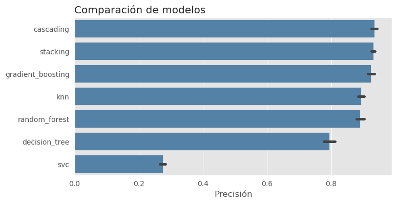

```python
acc_test_df = pd.DataFrame(acc_test)
acc_test_df = pd.melt(acc_test_df)
fig, ax = plt.subplots(figsize=(8, 4))
order = acc_test_df.groupby('variable')['value'].mean().sort_values(ascending=False).index
sns.barplot(data=acc_test_df, x='value', y='variable', color='steelblue', order=order, ax=ax)
ax.set_title('Comparación de modelos')
ax.set_xlabel('Precisión')
ax.set_ylabel('')
plt.show()
```

# Bibliografía

https://python.plainenglish.io/heteroscedasticity-analysis-in-time-series-data-fee51503cc0e

https://otexts.com/fpp2/autocorrelation.html

https://www.influxdata.com/blog/autocorrelation-in-time-series-data/